# Stat 479 Rough Draft Report

# Visualizations

## Total Tweet Analysis

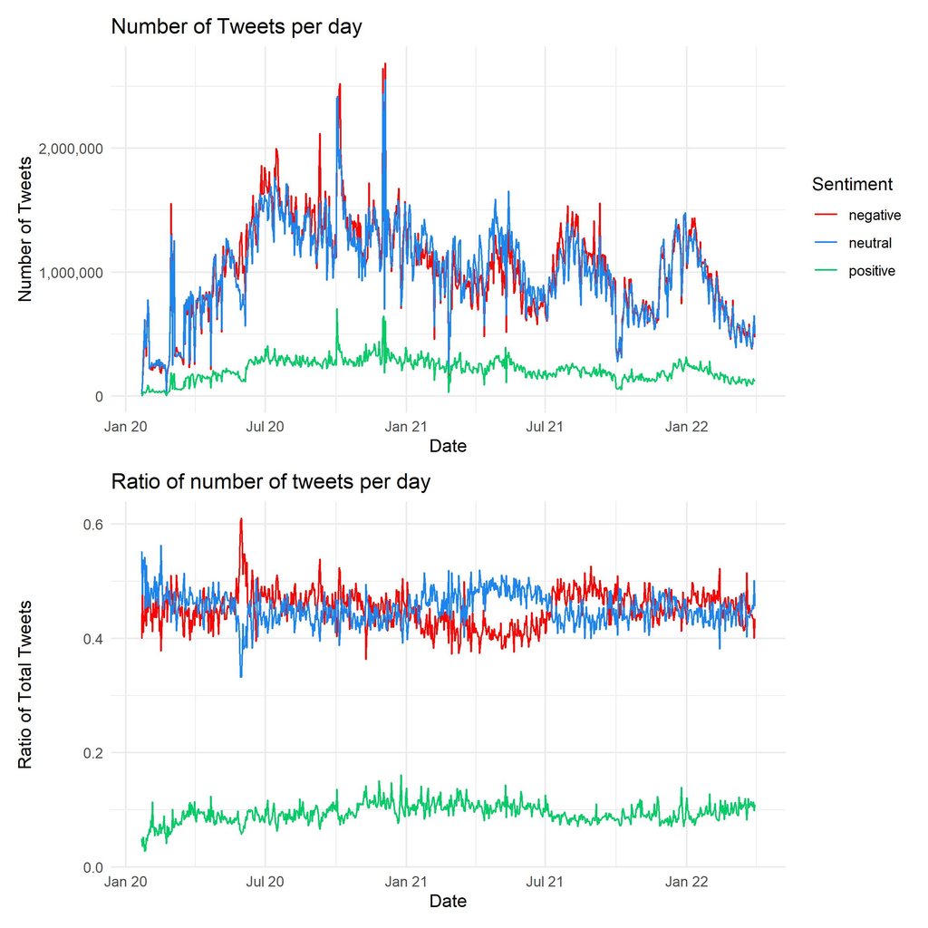

We noticed the counts of negative and neutral Tweets were higher, with the peak of negativity coming around July 2020 amist the first summer of the pandemic.

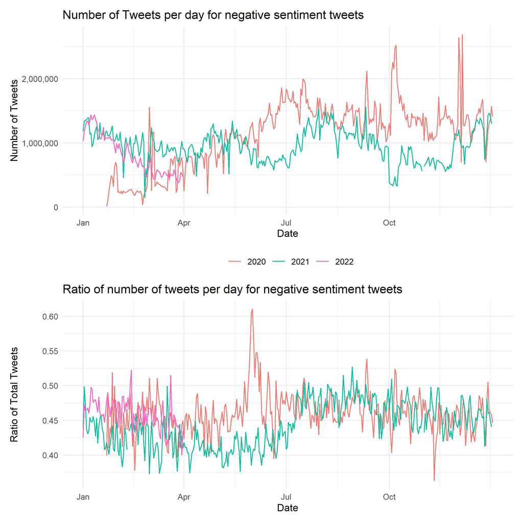

While incomplete for several months in 2022, we notice a gradual increase in the total number of negative Tweets for 2020, as well as the cyclic pattern illustrated in 2021 and partially in 2022.